# . Analysing RAPT4 vs RAPT3 . 🐍

#### - We will use Pandas to download the quotes for two stocks traded in the Brazilian Market (Bovespa/B3) RAPT4 and RAPT3 since the beginning of dec/2020 (12months)

#### - Use Matplotlib to plot the graph for these stocks

#### - Compare their performances

#### - Check Dividends paid in this period for each stock

#### - Get to a conclusion about which stock was a better investment in the past 12 months

```python
import pandas as pd
from pandas_datareader import data as web
```

```python
import matplotlib.pyplot as plt
```

# 1. Getting quotes for RAPT4

```python
dfrapt4 = web.DataReader('RAPT4.SA', data_source="yahoo", start = '12-01-2020', end = '11-26-2021')
display (dfrapt4)
```

| Date | High | Low | Open | Close | Volume | Adj Close |
| --- | --- | --- | --- | --- | --- | --- |
| 2020-12-01 | 14.95 | 14.41 | 14.72 | 14.78 | 5062800.0 | 14.144197 |
| 2020-12-02 | 14.93 | 14.43 | 14.82 | 14.80 | 2791100.0 | 14.163337 |
| 2020-12-03 | 15.06 | 14.55 | 14.90 | 14.55 | 2349300.0 | 13.924091 |
| 2020-12-04 | 14.88 | 14.51 | 14.67 | 14.79 | 2783700.0 | 14.153768 |
| 2020-12-07 | 15.89 | 14.71 | 14.83 | 15.59 | 6978400.0 | 14.919353 |
| ... | ... | ... | ... | ... | ... | ... |
| 2021-11-22 | 11.18 | 10.66 | 10.90 | 10.75 | 1465900.0 | 10.750000 |
| 2021-11-23 | 10.91 | 10.45 | 10.86 | 10.87 | 2323700.0 | 10.870000 |
| 2021-11-24 | 11.19 | 10.62 | 10.76 | 11.08 | 1659300.0 | 11.080000 |
| 2021-11-25 | 11.43 | 11.04 | 11.08 | 11.30 | 1792300.0 | 11.300000 |
| 2021-11-26 | 10.98 | 10.59 | 10.91 | 10.88 | 2149000.0 | 10.880000 |

235 rows × 6 columns

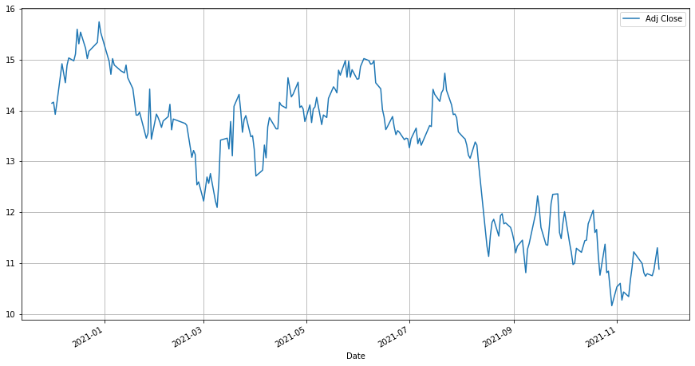

```python
dfrapt4["Adj Close"].plot(figsize=(15,8))
plt.legend()
plt.grid();
```

# 2. Getting quotes for RAPT3

```python
dfrapt3 = web.DataReader('RAPT3.SA', data_source="yahoo", start = '12-01-2020', end = '11-26-2021')
display (dfrapt3)
```

| Date | High | Low | Open | Close | Volume | Adj Close |
| --- | --- | --- | --- | --- | --- | --- |
| 2020-12-01 | 11.28 | 10.65 | 10.65 | 10.88 | 12600.0 | 10.298683 |
| 2020-12-02 | 10.96 | 10.88 | 10.95 | 10.96 | 2800.0 | 10.374408 |
| 2020-12-03 | 11.26 | 10.95 | 10.96 | 10.95 | 6900.0 | 10.364944 |
| 2020-12-04 | 11.28 | 10.91 | 11.28 | 11.04 | 1500.0 | 10.450134 |
| 2020-12-07 | 11.83 | 11.00 | 11.05 | 11.67 | 56700.0 | 11.046474 |
| ... | ... | ... | ... | ... | ... | ... |
| 2021-11-22 | 13.13 | 12.66 | 12.93 | 12.80 | 12800.0 | 12.800000 |
| 2021-11-23 | 13.10 | 12.83 | 13.10 | 13.05 | 3900.0 | 13.050000 |
| 2021-11-24 | 13.14 | 13.05 | 13.05 | 13.14 | 3200.0 | 13.140000 |
| 2021-11-25 | 13.20 | 12.85 | 13.09 | 13.20 | 1700.0 | 13.200000 |
| 2021-11-26 | 13.06 | 12.54 | 12.91 | 12.91 | 10000.0 | 12.910000 |

235 rows × 6 columns

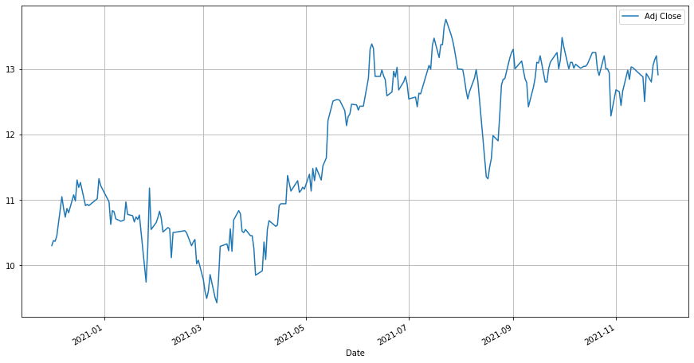

```python
dfrapt3["Adj Close"].plot(figsize=(15,8))
plt.legend()
plt.grid();
```

# 3. RAPT4 vs RAPT3

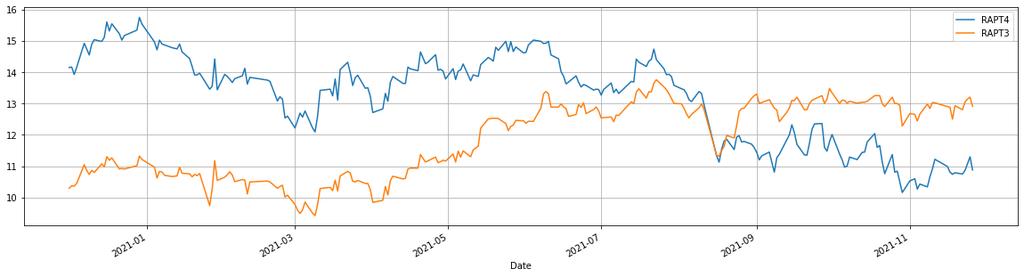

```python
dfrapt4["Adj Close"].plot(figsize=(20,5), label="RAPT4")
dfrapt3["Adj Close"].plot(figsize=(20,5), label="RAPT3")
plt.legend()
plt.grid();
```

##### (obs: for exact values, check the table/df)

#### *In the past 12months RAPT4 dropped from R$14 to R$11, that is: -21.5% .*

#### *While RAPT3 went from R$10.50 to 13, that is: +24%.*

#### *Maybe the reason is the Dividends Paid for each stock?*

# 4. Checking Dividends paid in the past 12 months:

#### *However, both stocks paid R$0.6491 in the past 12 months...*

[figure not shown]

# 5. Conclusion:

## Considering both stocks paid the same amount of dividends in the past 12 months, RAPT3 was by far a better investment than RAPT4!

#### Supposing the company anounced that it would start paying the same amount of dividends for both stock, it would make sense for their prices to converge; so both stocks would have the same Dividend Yield.

#### However, this is not what happened, RAPT3 is clearly over-valuated when compared to RAPT4. The final 3 on the ticker means this stock gives voting rights, but it does not justify such a valuation difference.

#### *Unless there are some investor with inside information about a possible future offer to buy this company's control...*

#### **--> My conclusion is that there is a lack of transparency here...**

**References:**

###### YouTube Channel: "Código Quant - Finanças Quantitativas" , Playlist: "Python para Investimentos":

###### https://youtube.com/playlist?list=PLCAhGm8nJ9CBn51o0x3j1p1LuMRqpeqCy

###### https://finance.yahoo.com/quote/RAPT4.SA/history?p=RAPT4.SA

###### https://statusinvest.com.br

###### https://www.w3schools.com/python/matplotlib_grid.asp

###### https://getemoji.com

###### https://stackoverflow.com

###### https://www.markdownguide.org/basic-syntax

###### https://medium.com/analytics-vidhya/the-ultimate-markdown-guide-for-jupyter-notebook-d5e5abf728fd